# Bar Chart

Vertical bar chart visualisation. Has a sort facility which can be used to order the bar chart by each of the measures or by the X axis values.

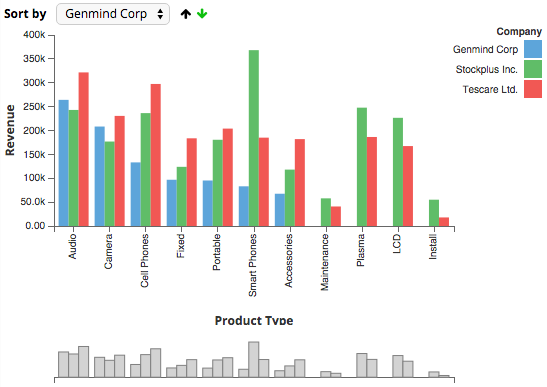

## Column Mapping

- **Category:** Single column to be used as the x-axis of the bar chart. Should contain discrete values.
- **Measure:** Aggregatable measure column to be used for the bar in the y-axis. Multiple measures can be selected, which will render multiple bars for each measure value in different colours. *Cannot* have multiple measures and a *Vary By Colour* column.
- **Vary By Colour:** Single column to pivot a *single* measure into multiple bars of different colours. Will **not** work when using multiple measures.

## Configuration

- **Wdith:** Numerical input for the width of the chart in pixels.
- **Height:** Numerical input for the height of the chart in pixels.
- **X Axis Title:** Text input for the title of the x-axis.
- **Y Axis Title:** Text input for the title of the y-axis.
- **Mini-Chart Navigator:** Boolean which if true will render a miniature chart underneath the original that can be used for navigation. The user can drag on the miniature chart to scroll and zoom the main chart.
- **Show Legend:** Boolean which if true, will show the legend.
- **Colour (1-6):** Colours of the bars, in order of implementation. If more than 6 measures are present, the colours will loop over these 6.

## Actions

- **Click - Bar:** Click on a bar to trigger a reaction. If Vary By Colour is defined, it will pass both the category and the variation data to the reaction.
- **Hover - Bar:** Hover over a bar to trigger a reaction. If Vary By Colour is defined, it will pass both the category and the variation data to the reaction.
- **Click - Section:** Click on a section, anywhere over the white space above a group of bars to trigger a reaction. This can only pass the category data.
- **Hover - Section:** Hover on a section, anywhere over the white space above a group of bars to trigger a reaction. This can only pass the category data.
- **Click - Group:** Click on a bar to pass a single value and Ctrl-click to select multiple at once. Each click will trigger a reaction. If Vary By Colour is defined, it will pass both the category and the variation data to the reaction.
- **Brush Select:** Select category values using the miniature navigation chart. Releasing the mouse after resizing or moving the window on the mini-chart will trigger the reaction.

## Reactions

- **Filter:** Will execute the query again (against the BI Server/database), filtering (if possible) on the input data.
- **Highlight Bars:** Highlights all of the bars matching the input data.

# Horizontal Bar Chart

Horizontal bar chart visualisation. Has a sort facility which can be used to order the bar chart by each of the measures or by the Y axis values.

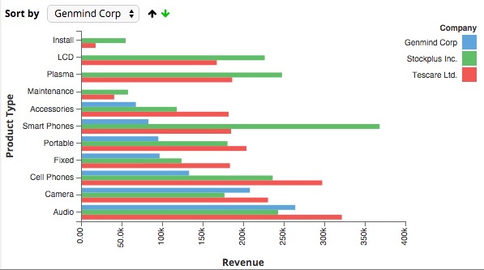

## Column Mapping

- **Category:** Single column to be used as the y-axis of the bar chart. Should contain discrete values.
- **Measure:** Aggregatable measure column to be used for the bar in the x-axis. Multiple measures can be selected, which will render multiple bars for each measure value in different colours. *Cannot* have multiple measures and a Vary By Colour column.
- **Vary By Colour:** Single column to pivot a *single* measure into multiple bars of different colours. Will **not** work when using multiple measures.

## Configuration

- **Width:** Numerical input for the width of the chart in pixels.
- **Height:** Numerical input for the height of the chart in pixels.
- **X Axis Title:** Text input for the title of the x-axis.
- **Y Axis Title:** Text input for the title of the y-axis.
- **Mini-Chart Navigator:** Boolean which if true will render a miniature chart underneath the original that can be used for navigation. The user can drag on the miniature chart to scroll and zoom the main chart.
- **Show Legend:** Boolean which if true will show the legend.
- **Colour (1-6):** Colours of the bars, in order of implementation. If more than 6 measures are present, the colours will loop over these 6.

## Actions

- **Click - Bar:** Click on a bar to trigger a reaction. If Vary By Colour is defined, it will pass both the category and the variation data to the reaction.
- **Hover - Bar:** Hover over a bar to trigger a reaction. If Vary By Colour is defined, it will pass both the category and the variation data to the reaction.
- **Click - Section:** Click on a section, anywhere over the white space above a group of bars to trigger a reaction. This can only pass the category data.
- **Hover - Section:** Hover on a section, anywhere over the white space above a group of bars to trigger a reaction. This can only pass the category data.
- **Click - Group:** Click on a bar to pass a single value and Ctrl-click to select multiple at once. Each click will trigger a reaction. If Vary By Colour is defined, it will pass both the category and the variation data to the reaction.
- **Brush Select:** Select category values using the miniature navigation chart. Releasing the mouse after resizing or moving the window on the mini-chart will trigger the reaction.

## Reactions

- **Filter:** Will execute the query again (against the BI Server/database), filtering (if possible) on the input data.
- **Highlight Bars:** Highlights all of the bars matching the input data.

# Line Chart

Line chart visualisation, can be used as an area chart by setting the appropriate configuration.

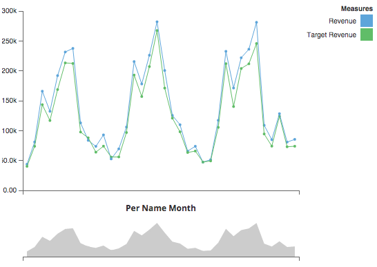

## Column Mapping

- **Category:** Single column to be used as the x-axis of the line chart. Should contain continuous values.
- **Measure:** Aggregatable measure column to be used for the line in the y-axis. Multiple measures can be selected, which will render multiple lines for each measure value in different colours. *Cannot* have multiple measures and a Vary By Colour column.
- **Vary By Colour:** Single column to pivot a *single* measure into multiple lines of different colours. Will **not** work when using multiple measures.

## Configuration

- **Width:** Numerical input for the width of the chart in pixels.
- **Height:** Numerical input for the height of the chart in pixels.
- **Point Size:** Radius of the points to display in pixels.
- **Show Legend:** Boolean which if true will show the legend.
- **Second Axis:** Boolean which if true will display a second axis on the right hand side of the chart. This will only work if specifically **two** measures have been defined, and is **not** compatible with vary by colour.
- **Drag Select:** Boolean which if true allows the user to drag on the main chart area to zoom into that are of the chart.
- **Mini-Chart Navigator:** Boolean which if true will render a miniature chart underneath the original that can be used for navigation. The user can drag on the miniature chart to scroll and zoom the main chart.
- **Shade Area:** Boolean which if true shades the area under the line.
- **Colour (1-6):** Colours of the lines, in order of implementation. If more than 6 measures are present, the colours will loop over these 6.

## Actions

- **Click - Section:** Click on a section, the whitespace (or shaded area) of the chart which can pass the category values to the reaction.
- **Hover - Section:** Hover over a section, the whitespace (or shaded area) of the chart which can pass the category values to the reaction.
- **Click - Point:** Click on a specific point in the chart to trigger a reaction and pass the category value as well as the variation value if Vary By Colour has been defined.
- **Hover - Point:** Hover over a specific point in the chart to trigger a reaction and pass the category value as well as the variation value if Vary By Colour has been defined.
- **Brush Select:** Select category values using the miniature navigation chart. Releasing the mouse after resizing or moving the window on the mini-chart will trigger the reaction.

## Reactions

- **Filter:** Will execute the query again (against the BI Server/database), filtering (if possible) on the input data.

# Line/Bar Chart

Displays a bar and line chart on the same plot, with two `y` axes.

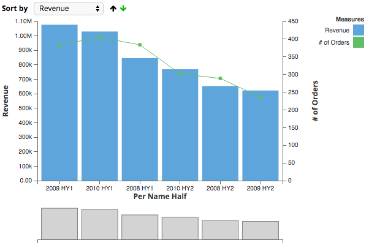

## Column Mapping

- **Category:** Single column to be used as the x-axis of the bar chart. Should contain discrete values.
- **Bar Measure:** Aggregatable measure column to be used for the line in the y-axis. Multiple measures can be selected, which will render multiple bars for each measure value in different colours.
- **Line Measure:** Aggregatable measure column to be used for the line in the y-axis. Multiple measures can be selected, which will render multiple lines for each measure value in different colours.

## Configuration

- **Width:** Numerical input for the width of the chart in pixels.
- **Height:** Numerical input for the height of the chart in pixels.
- **Point Size:** Radius of the points to display in pixels.
- **X Axis Title:** Text input for the title of the x-axis.
- **Y Axis Title:** Text input for the title of the left y-axis.
- **Second Y Axis Title:** Text input for the title of the right y-axis.
- **Mini-Chart Navigator:** Boolean which if true will render a miniature chart underneath the original that can be used for navigation. The user can drag on the miniature chart to scroll and zoom the main chart.
- **Show Legend:** Boolean which if true will show the legend.
- **Colour (1-6):** Colours of the bars, in order of implementation. If more than 6 measures are present, the colours will loop over these 6.

## Actions

- **Click - Bar:** Click on a bar to trigger a reaction. If Vary By Colour is defined, it will pass both the category and the variation data to the reaction.
- **Hover - Bar:** Hover over a bar to trigger a reaction. If Vary By Colour is defined, it will pass both the category and the variation data to the reaction.
- **Click - Section:** Click on a section, the whitespace (or shaded area) of the chart which can pass the category values to the reaction.
- **Hover - Section:** Hover over a section, the whitespace (or shaded area) of the chart which can pass the category values to the reaction.
- **Click - Point:** Click on a specific point in the chart to trigger a reaction and pass the category value as well as the variation value if Vary By Colour has been defined.
- **Hover - Point:** Hover over a specific point in the chart to trigger a reaction and pass the category value as well as the variation value if Vary By Colour has been defined.
- **Brush Select:** Select category values using the miniature navigation chart. Releasing the mouse after resizing or moving the window on the mini-chart will trigger the reaction.
- **Click - Group:** Click on a bar to pass a single value and Ctrl-click to select multiple at once. Each click will trigger a reaction. If Vary By Colour is defined, it will pass both the category and the variation data to the reaction.

## Reactions

- **Filter:** Will execute the query again (against the BI Server/database), filtering (if possible) on the input data.
- **Highlight Bars:** Highlights all of the bars matching the input data.

# Table

Basic table visualisation, created using the [DataTables](https://www.datatables.net/) plugin to create a paginated table of results. Features include sorting by column and searching by text. Neither of these require going back to the database.

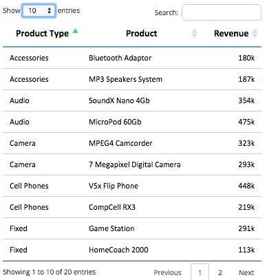

## Column Mapping

- **Columns:** Choose multiple columns to add to the table. Will display left to right in the order selected here.
- **Hidden:** Can use hidden columns that will not display in the table but will affect the data set. Can be used to conditionally format data based on undisplayed information.

## Configuration

- **Theme Colour:** Sets the colour for the table. Will have a solid line below the header and a lighter shade of the colour for a hover over of each row.
- **Font:** String input for the font to display the table in.
- **Font Size:** Size of the font to display in the table.
- **Initial Rows Displayed:** Number of rows to display on each page in the table. Can be changed in the drop down once rendered.

## Actions

- **Click - Row:** Click on a row in the table to pass the relevant columns.
- **Hover - Row:** Mouse over a row to pass the chosen columns.

## Reactions

- **Filter:** Will execute the query again (against the BI Server/database), filtering (if possible) on the input data.
- **Search:** Uses the in-memory search facility of the table. Does not query the BI server/database.

# Pivot Table

Pivot table created using a modified version of Nicolas Kruchten's [JS plugin](https://github.com/nicolaskruchten/pivottable).

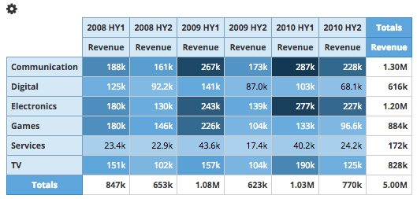

Users can click the settings button (cog icon) near the top left of the table. This will switch to a configuration view, which can be used to change aggregations and remap attributes as rows or columns or exclude them entirely. The eye icon near the measure names can be used to show or hide the measures (totals will always be displayed). The dropdown menu in the top left will allow the user to switch between the table and table/bar views.

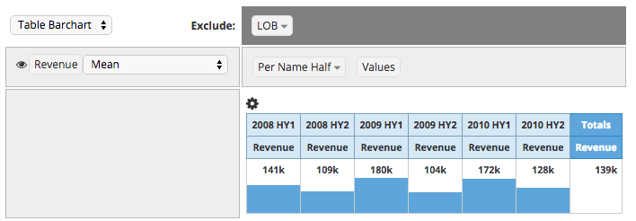

## Column Mapping

- **Rows:** Attributes to be shown as rows in the pivot table. Can select multiple.
- **Columns:** Attributes to be shown as columns in the pivot table. Can select multiple.
- **Measures:** Measures to display in the cells. Must be numeric measures that can be aggregated. Can choose multiple.
- **Hidden Measures:** Meaures that are in the dataset but are not displayed in the table. This can be used for conditionally formatting rows based on certain columns.

## Configuration

- **Default Aggregator:** Initial aggregation rule set for the cells.
- **Hide Controls:** Show/hide the control panel upon rendering.
- **Values As Columns:** Boolean to choose to display value headings as columns or rows.
- **Theme Colour:** Colour scheme for the table.

## Conditional Formatting

- **Heatmap:** Colours cells in table based on value. As such a value for the formatting rule is not required, instead the root colour should be chosen.

## Actions

**No** interaction triggers at this time.

## Reactions

- **Filter:** Will execute the query again (against the BI Server/database), filtering (if possible) on the input data.

# Scatter Chart

Scatter chart visualisation, displaying points on a plot space of two measures against one another. Can be used as a bubble chart as well by setting a third measure to be the size variable. Also can calculate a linear regression and R-squared value indicated correlation.

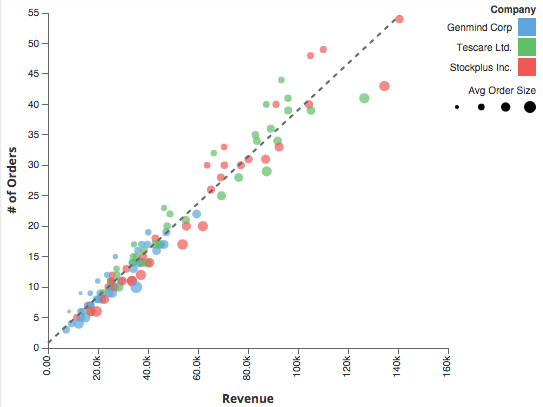

## Column Mapping

- **Measure X:** Measure to select on the X axis. Currently does not support attribute information here.
- **Measure Y:** Measure to display on the Y axis.
- **Group By:** Attribute to group the measures by. Will determine the number of points plotted. If no attribute was selected here, OBIEE would aggregate the two measures into a single point.
- **Vary By Colour:** Will vary the colour of the points based on the attribute selected.
- **Vary By Size:** Will vary the size of hte points based on the measure selected. This will effectively turn the chart into a bubble chart.

## Configuration

- **Width:** Numerical input for the width of the chart in pixels.
- **Height:** Numerical input for the height of the chart in pixels.
- **Minimum Point Size:** Minimum radius for the points.
- **Maximum Point Size:** Maximum radius for the points. Only relevant if *Vary By Size* has been populated.
- **Drag To Select:** Allows functionality to drag plot area, selecting points in the area and aggregating the values of each selected point.
- **Linear Regression:** Calculates linear regression for the chart, displaying a dashed line for the correlation and the R-squared value when hovering over the line.
- **X Axis Title:** Text input for the title of the x-axis.
- **Y Axis Title:** Text input for the title of the y-axis.
- **Colour (1-6):** Colours of the points, colours past 1 are only relevant if *Vary By Colour* is populated.

## Actions

- **Selection Box:** Select a group of points using a drag-select rectangle.
- **Hover - Point:** Mouseover a point on the chart.
- **Click - Point:** Click on a point on the chart.

## Reactions

- **Filter:** Will execute the query again (against the BI Server/database), filtering (if possible) on the input data.
- **Highlight Points:** Makes matching points on the chart larger and slightly darker in colour.

# Pie Chart

Pie/donut chart visualisation. Can hover over slices for tooltip information.

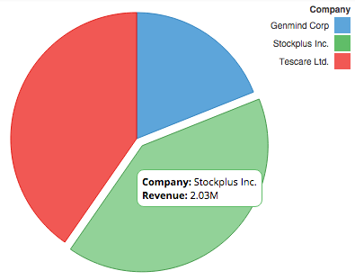

## Column Mapping

- **Category:** Attribute with which to group the slices.
- **Measure:** Measure affecting hte size of each slice.

## Configuration

- **Size:** Radius of the pie chart.
- **Inner Radius:** Cutaway in the centre of the pie, turning it into a donut shape.
- **Colour (1-6):** Colours of the slices. Will cycle through the colours if enough slices exist.

## Actions

- **Click - Slice:** Click on a slice to pass data.

## Reactions

- **Filter:** Will execute the query again (against the BI Server/database), filtering (if possible) on the input data.

# Measure Tile

Measure tile displaying aggregated numerical figures. Has built in conditional formatting (i.e. not using the generic framework yet) between configured values which display up/down arrows and fade to the configured colours. Animates the number count from 0 to the value.

## Column Mapping

- **Measure:** Single, aggregatable measure to display.

## Configuration

- **Number Font:** Font to display the number in.
- **Font Size:** Size of the number and label.
- **Normal Range:** Range between which the number will display in black with no arrow.
- **Positive Colour:** If above the normal range, will display in this colour.
- **Negative Colour:** If belwo the normal range, will display in this colour.

## Actions

None.

## Reactions

- **Filter:** Will execute the query again (against the BI Server/database), filtering (if possible) on the input data.

# Word Cloud

Word cloud (also known as tag cloud or weighted) list visualisation. Here the attribute word will be sized based on the equivalent measure value. The positioning on the canvas is determined by one of two configurable algorithms. The word colours are also configurable.

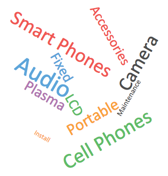

## Column Mapping

- **Word:** Attribute column representing the words for the cloud.
- **Frequency:** Measure column giving the data for the size weightings.

## Configuration

- **Layout Algorithm:** Either *Archimedean* or *Rectangular*, chooses that algorithm that determines the positioning of the words on the canvas.
- **Sizing Scale:** Chooses either linear or log scale for sizing.
- **Size Range:** Range of font sizes for the tags.
- **Font:** Font of the word tags.
- **Width:** Width of the canvas in pixels.
- **Height:** Height of the canvas in pixels
- **Word Orientations:** Choose a number of orientations between the given angles (min -90, max 90).
- **Colour (1-6):** Colours of the words, will cycle through the colours if more words exist than colours in the palette.

## Actions

- **Click - Word:** Click a word to trigger an interaction.
- **Hover - Word:** Mouseover a word to trigger an interaction.

## Reactions

- **Filter:** Will execute the query again (against the BI Server/database), filtering (if possible) on the input data.

# Sankey Diagram

Plots a [Sankey diagram](https://en.wikipedia.org/wiki/Sankey_diagram) which is a specific type of flow diagram where the width of the arrows are shown proportionally to the flow quantity. With OBIEE, this is particularly useful to show hierarchical information. A single query will be executed, with the parent levels aggregated in Javascript. Can hover over flows for tooltip information.

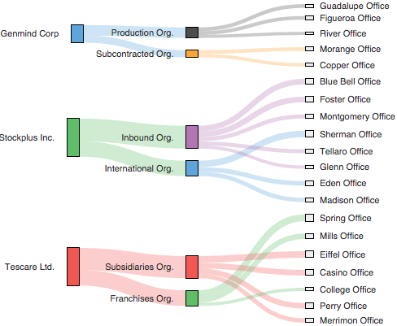

## Column Mapping

- **Level (From-To):** Attribute columns representing each level in the data flow.
- **Measure:** Single measure column, determining widths of the flow.

## Configuration

- **Width:** Width of the canvas in pixels.
- **Height:** Height of the canvas in pixels.
- **Colour (1-6):** Colours of the flow objects. Will cycle through the colours if there are more than 6 different flows.

## Actions

Currently **no** actions available.

## Reactions

- **Filter:** Will execute the query again (against the BI Server/database), filtering (if possible) on the input data.

# Map - Bubbles

Map visualisation using open source plugin [LeafletJS](http://leafletjs.com/). This shows bubbles based on points positioned by longitude and latitude and sized based on a measure value. Hovering over the bubbles will display a tooltip. Clicking the pencil icon at the top of the map will allow the user to select multiple points by drawing a shape freehand.

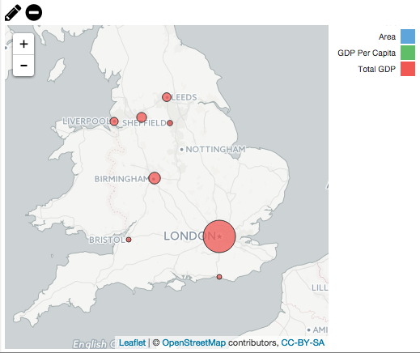

## Column Mapping

- **Description:** Attribute column giving the descriptive name for a point.
- **Longitude:** Longitude attribute for positioning the points.
- **Latitude:** Latitude attribute for positioning the points.
- **Measure:** Measure attribute scaling the size of the points. Choosing multiple measure will allow the legend to act as a measure selector.

## Configuration

- **Width:** Width of the map in pixels.
- **Height:** Height of the map in pixels.
- **Highlight Colour:** Colour of the points once highlighted.
- **Colour (1-6):** Colours of the bubbles. Will apply to the multiple measures and be displayed in the legend on the right.

## Actions

- **Click Bubble:** Click on a bubble to pass the description.
- **Freehand Select:** Use the freehand select tool to pass through multiple values to the target.

## Reactions

- **Filters:** Will execute the query again (against the BI Server/database), filtering (if possible) on the input data.

# Map - Choropleth

Map visualisation using open source plugin [LeafletJS](http://leafletjs.com/). This shows regions coloured as a heatmap, darker colours for higher values and vice versa. Hovering over the regions will display a toolip. Works by using a [topoJSON](https://github.com/mbostock/topojson) file uploaded to the deployment on the server (in the `topojson` folder). This file will have the description of the regions as well as an attribute that can be used to tie hte OBIEE dataset to the map.

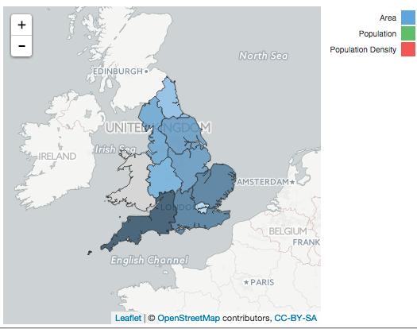

## Column Mapping

- **Code:** Attribute representing the code that matches the attribute in the topoJSON file.
- **Description:** Descriptive field for a given region.
- **Measure:** Measure values used to colour the regions. Darker colours represent higher values and vice versa. Choosing multiple measures will cause the legend to become column selector.

## Configuration

- **Width:** Width of the map in pixels.
- **Height:** Height of the map in pixels.
- **TopoJSON File:** TopoJSON file existing in the `topojson` directory.
- **Feature Code:** TopoJSON attribute linking the OBIEE dataset to the map.
- **Feature Description:** Description attribute from the topoJSON file.
- **Null Colour:** Colour for regions which do not map to any rows in the OBIEE dataset.
- **Colour (1-6):** Colours of the heatmap for each measure. Multiple measures will cycle through the colours in this palette.

## Actions

- **Click Feature:** Click on a region to pass the data to the target.

## Reactions

- **Filters:** Will execute the query again (against the BI Server/database), filtering (if possible) on the input data.